# WHO Measles Investigation – Looking at Socioeconomic Indicators and Measles Incidences Globally

- Show All Code
- Hide All Code
- View Source

Author

Libby Brill, Emi Degembe, Alvaro Ramos

Published

May 9, 2026

# Introduction On MMR

Measles is a highly contagious respiratory infection caused by the measels virus. The spread of the virus is often through respiratory droplets and can remain in the air for up to 2 hours. While children are the most commonly affected, those who are unvaccinated, pregnant, or immunocompromised are at an increased risk. Typical symptoms include fever, congestion, cough, red eyes, and rash. Complications have led to hospitalization, pneumonia, or even a brain infection.[^1]

Rubella is also a high contagious viral infection spread through airborne droplets or even direct contact with infected mucus from the nose or throat. Compared to measels, there are similar symptoms, though rubella is most known for its distinct rash pattern. Though Rubella is a mild infection for most, pregnant mothers can pass the infection to their unborn child, which can lead to severe complications. Congenital rubella symptoms include miscarriages, stillbirths, growth delays, deafness, problems in organ formation including the heart, or even learning difficulties.[^2]

Both do not have treatments so if infected, the patient must let the virus run its course. The most common prevention method is through the Measles-Mumps-Rubella (MMR) vaccine which is often given to children between 12-15 months and again between 4-6 years old. This vaccine protects against the three viral infections for life and can prevent Rubella during pregnancies.[^3]

# Methodologies & Data Cleaning

## Main dataset: WHO Provisional Measles Cases

The data comes from the World Health Organization’s Provisional monthly measels and rubella data, which contains information on those who were suspected to have the virus, were tested for the virus, and confirmed had the virus. The data includes cases from as early as 2012 and as recent as 2025, collected globally by the organization. The measles case testing follows the World Health Organization (WHO)’s [Measles Programmatic Risk Assessment Tool](https://www.who.int/teams/immunization-vaccines-and-biologicals/immunization-analysis-and-insights/surveillance/measles-programmatic-risk-assessment-tool) where they further collect samples as necessary. The table below breaks down each identified case method following the assessment of a suspected case:

[output not shown]

Below is the cleaning script provided by the [GitHub repository](https://github.com/rfordatascience/tidytuesday/blob/main/data/2025/2025-06-24/readme.md) which the data came from. The data were cleaned by Jen Richmond for one of the tidytuesday’s datasets which form two different datasets. One represents the total number of measles and rubella cases for different years, countries, and regions (`cases_year`), and the other (`cases_month`) represents the number of measles and rubella cases for different months of a year. Most of the data cleaning done by Jen Richmond includes renaming the variables to make variable names more informative and assigning variables to different data types. In `cases_month`, the main cleaning that was done was converting all column names to snake case with `clean_names()`, ensuring consistent naming across all columns. Additionally, the mutate line converts all columns from year to discarded into numerical values. In `cases_year`, the first row of data was established as the column names then did the same snake case naming standardization. The column names were then renamed to column names that described what data is contained in the columns. For example, what used to be column name `na` is now `measels_lab_confirmed` which is far more understandable than what it was called in the raw data. Finally, the first row of data (not the column names that were just renamed) was dropped.

```r
cases_month <- readr::read_csv('https://raw.githubusercontent.com/rfordatascience/tidytuesday/main/data/2025/2025-06-24/cases_month.csv')
cases_year <- readr::read_csv('https://raw.githubusercontent.com/rfordatascience/tidytuesday/main/data/2025/2025-06-24/cases_year.csv')
```

```r
########## HELPER FUNCTIONS ##########
######################################

# using the same summ_stats as practice activity 2
summ_stats <- function(x) {

    # if x contains numeric values
      # return a tibble with the mean, med, sd, IQR, and n observed
    if (is.numeric(x)) {
        out_df <- tibble(
            mean = mean(x, na.rm = TRUE),
            median = median(x, na.rm = TRUE),
            stdev = sd(x, na.rm = TRUE),
            iqr = IQR(x, na.rm = TRUE),
            n = sum(!is.na(x)) # length won't work bc of NAs
        )
    # if x contains categorical, return tibble with # of levels in variable
    } else if (is.factor(x) || is.character(x)) {
        out_df <- tibble(
            n_levels = n_distinct(x)
        )
    } else {
        stop("Inputted values are not numeric or categorical.")
    }

    #return the data frame.
    out_df
}

summarize_stats <- function(df, col = measles_lab_confirmed, mode = region) {
  ######### PARAMETERS ##########
  # input: df -- the dataframe of interest
  # col: column of interest to summarize by:
  #   measels_suspect,
  #   measels_clinical,
  #   measels_epi_linked,
  #   measels_lab_confirmed [DEFAULT],
  #   measels_total
  # mode: aggregate by options:
  #   region [DEFAULT],
  #   country,
  #   iso3,
  #   year
  ###############################

  df |>
    select({{mode}}, {{col}}) |>
    group_by({{mode}}) |>
    #group_map removed the group column, so to retain that, group_modify.
    # See second example: https://dplyr.tidyverse.org/reference/group_map.html
    group_modify( ~ summ_stats(.x |>
                              pull({{col}}))) |>
    bind_rows()
}
```

## International Monetary Fund Providing GDP Per Capita Context

The International Monetary Fund is an international financial institution of the United Nations. The organization provides policy advice, financial assistance, and capacity development to its 191 member countries, and therefore collects financial data in order to perform necessary research. We are specifically focused on GDP per capita for each country, for which information has been recorded from 1980 to present day. The data was pulled with an API, which can be viewed on the web [here](https://www.imf.org/external/datamapper/api/v1/NGDPDPC).

```r
# API call
data <- GET("https://www.imf.org/external/datamapper/api/v1/NGDPDPC")

# creating function to make tibbles for each country from json data
country_values <- function(country){

  tibble(json = list(parse_json(data))) |>
    unnest_wider(json) |>
    unnest_longer(values) |>
    unnest_wider(values) |>
    slice_head() |>
    select({{country}}) |>
    unnest_longer({{country}}) |>
    rename(year = str_glue("{country}_id")) |>
    pivot_longer(cols = {{country}},
                 names_to = "iso3",
                 values_to = "GDP_per_capita"
                 ) |>
    mutate(year = as.numeric(year))

}

# storing countries available in both the cases_year dataset and json data
ids <- cases_year$iso3 |>
  as.factor() |>
  levels()

ids <- ids[ids %in% (
  tibble(json = list(parse_json(data))) |>
    unnest_wider(json) |>
    unnest_longer(values) |>
    unnest_wider(values) |>
    slice_head() |>
    names()
  )]

# creating dataset from json data for each country and merging to one
data <- map(.x = ids,
            .f = country_values
            ) |>
  bind_rows()

# join to cases_year dataset to include all data
dataset <- cases_year |>
  full_join(data) |>
  filter(year >= 2012) #|>
  #mutate(region_info = fct_recode(
    #region,
    #"Africa" = "AFRO",
    #"Americas" = "AMRO",
    #"Eastern Mediterranean" = "EMRO",
    #"Europe" = "EURO",
    #"South East Asia" = "SEARO",
    #"Western Pacific" = "WPRO"
    #)
    #)
```

## WHO MCV Course 2 Vaccination Records

The WHO has recorded the estimated immunization coverage for each year based on various sources from 2003-2024. This estimated coverage is defined as the percentage of children who have received both doses of the measles containing vaccine (MCV2) in a given year, based on the recommended schedule for that nation. More information on the method of estimation is outlined in the Metadata section of the website, but these estimations are useful indicators in tracking the disease reduction efforts. The API link for the data that is displayed on the website can be found [here](https://ghoapi.azureedge.net/api/MCV2).

```r
data <- GET("https://ghoapi.azureedge.net/api/MCV2")

data <- tibble(json = list(parse_json(data))) |>
  unnest_wider(json) |>
  unnest_wider(value, names_sep = "_") |>
  select(-"@odata.context")
```

```r
row <- function(v){
  data |>
    select(v) |>
    unnest_wider(v) |>
    select(ParentLocationCode,
           #ParentLocation,
           SpatialDim,
           TimeDim,
           #Value,
           NumericValue
           )
}
```

```r
data <- map(.x = data |> names(),
            .f = row
            ) |>
  bind_rows() |>
  rename(
    "region" = ParentLocationCode,
    #"region_info" = ParentLocation,
    "iso3" = SpatialDim,
    "year" = TimeDim,
    #value = Value,
    "mcv2" = NumericValue
  )
```

```r
metadata <- dataset |>

  # join to cases_year dataset
  full_join(data |> select(-region),
            by = join_by(iso3, year)
            ) |>
  filter(year >= 2012) |>
  mutate(mcv2 = mcv2 / 100) |>

  # recoding region to be more informative
  mutate(
    region_s = region,
    region = fct_recode(
      region,
      "Africa" = "AFRO",
      "Americas" = "AMRO",
      "Eastern Mediterranean" = "EMRO",
      "Europe" = "EURO",
      "South East Asia" = "SEARO",
      "Western Pacific" = "WPRO"
      )
    ) |>

  mutate(p_lab_total = measles_lab_confirmed / measles_total)

write.table(metadata, file = "metadata.txt")
```

# Determining Identified Measles Cases Across Regions

**Research Question**: Which regions have the highest number of identified measles cases and what proportion are identified cases?

Below, we present a data analysis observing which regions have the highest proportion of identified measles cases. Given the context of the data, both lab and epidemiologically-linked are properly evaluated by a health-care provider whereas clinical cases are based on symptoms and thus, hold a level of skepticism. We will be considering clinically linked cases, however, they will not be considered identified.

```r
summarize_stats(metadata |> filter(!(is.na(region))),
                measles_incidence_rate_per_1000000_total_population,
                region
                ) |>
  ungroup() |>
  arrange(-mean) |>
  gt() |>
  fmt_number(columns = -c(region, n),
             decimals = 2) |>
  cols_label("region" = "Region",
             "mean" = "Mean",
             "median" = "Median",
             "stdev" = "Standard Deviation",
             "iqr" = "IQR",
             "n" = "Sample Size",
             ) |>
  tab_style(
    style = cell_text(weight = "bold"),
    locations = cells_column_labels()
    ) |>
  tab_style(
    style = cell_text(style = "italic", decorate = "underline"),
    locations = cells_row_groups()
    ) |>
  tab_header(
    title = md("Summary Statistics for Total Number of Measles Cases for Each
               1 Million Individuals")
  ) |>
  data_color(
    columns = "mean",
    method = "numeric",
    palette = c("#CCEEDF", "#BAE8D4", "#A8E2CA",
                "#96DCBF", "#83D6B5", "#6ED0AB",
                "#57CAA1", "#3BC397", "#00BD8D"
                )
    )
```

Summary Statistics for Total Number of Measles Cases for Each 1 Million Individuals

| Region | Mean | Median | Standard Deviation | IQR | Sample Size |
| --- | --- | --- | --- | --- | --- |
| Western Pacific | 78.34 | 0.14 | 670.59 | 5.14 | 341 |
| Europe | 57.75 | 2.32 | 242.69 | 12.72 | 678 |
| Africa | 57.66 | 13.36 | 325.49 | 38.30 | 601 |
| Eastern Mediterranean | 56.07 | 8.86 | 163.68 | 34.93 | 286 |
| South East Asia | 15.91 | 4.98 | 26.22 | 17.81 | 149 |
| Americas | 2.26 | 0.00 | 14.84 | 0.00 | 327 |

Using table 1 to compare the number of total measles cases for each 1 million individuals between the different regions, we see that the region averaging the largest number seems to be the Western Pacific and the region averaging the smallest number seems to be the Americas. Addressing the research question, Western Pacific overall seems to demonstrate the largest number of total measles cases. We investigated further by observing the proportion of measles cases by region, excluding those that were clinically symptomatic.

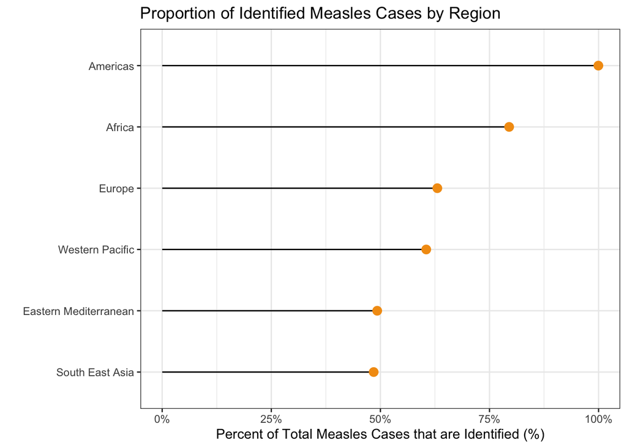

```r
metadata |>
  filter_out(is.na(region)) |>
  group_by(region) |>
  summarize(confirmed_cases = sum(measles_epi_linked + measles_lab_confirmed),
            prop_confirmed = confirmed_cases/sum(measles_total)) |>
  mutate(region = fct_reorder(region, prop_confirmed)) |>
  ggplot(aes(x = prop_confirmed, y = region)) +
  geom_segment(aes(x = 0, xend = prop_confirmed)) +
  geom_point(color = "#f39c12", size = 3) +
  scale_x_continuous(labels = label_percent()) +
  labs(title = "Proportion of Identified Measles Cases by Region",
       x = "Percent of Total Measles Cases that are Identified (%)",
       y = "",
       alt = "A lollipop plot displaying the percent of total meales cases that are identified by region. Americas has the highest percentage with nearly all total measles cases confirmed. Eastern Mediterranean and South East Asia have the lowest percentages at just below 50%.") +
  theme_bw()
```

Figure 1 shows that the Americas have the highest proportion of validated cases with a near 100% confirmation rate. This suggests a very strong diagnostic infrastructure where almost every suspected case is officially verified. The Eastern Mediterranean and South East Asia regions show the lowest proportions, with both falling just under the 50% mark. This means that more than half of the measles cases in these regions remain unconfirmed by lab or epidemiological links.

We then further investigated the specific confirmation types, comparing the split of clinically, epidemiologically-linked, and lab confirmed measles cases in each region.

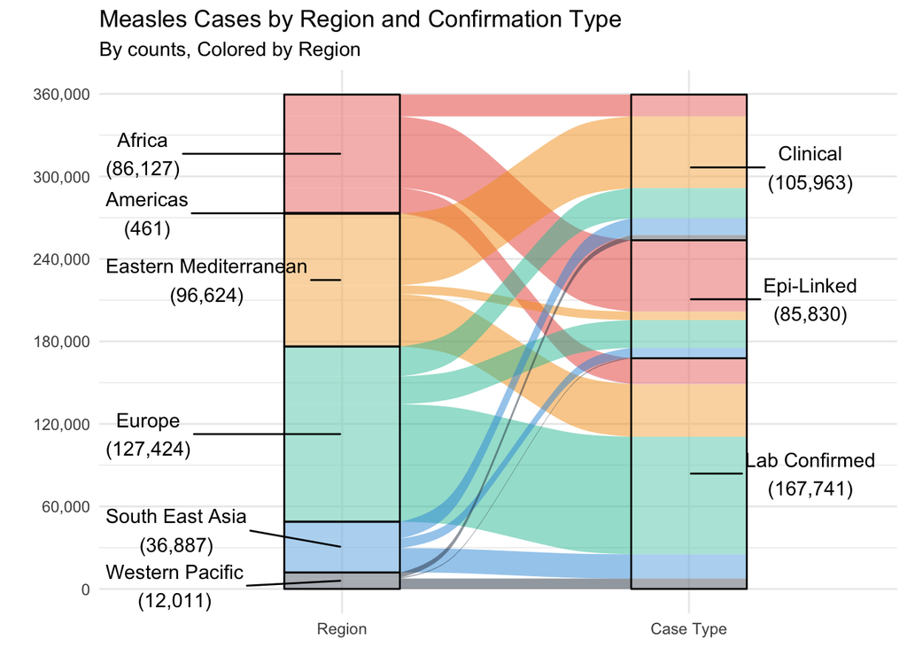

**Figure 2.** Alluvial plot displaying the measles cases by region and the method of case confirmation.

```r
metadata |>
  filter(year == 2024, !is.na(region)) |>
  group_by(region) |>
  summarize(
    region_measles_total = sum(measles_total),
    region_lab_confirmed = sum(measles_lab_confirmed),
    region_epi_linked = sum(measles_epi_linked),
    region_clinical = sum(measles_clinical)
  ) |>
  pivot_longer(
    cols = c(region_lab_confirmed, region_epi_linked, region_clinical),
    names_to = "type",
    values_to = "count"
  ) |>
  mutate(
    type = recode(type,
      region_lab_confirmed = "Lab Confirmed",
      region_epi_linked = "Epi-Linked",
      region_clinical = "Clinical"
    )
  ) |>
  ggplot(aes(axis1 = region, axis2 = type, y = count)) +
  geom_alluvium(aes(fill = region)) +
  geom_stratum(alpha = .2) +
  scale_fill_manual(
    values = c("#e74c3c", "#CC79A7", "#f39c12",
               "#29c1a3", "#3498db", "#2c3e50")
  ) +
  geom_text_repel(
    aes(label = ifelse(
      after_stat(x) == 1,
      paste0(as.character(after_stat(stratum)), "\n(", as.character(comma(after_stat(count))), ")"),
      NA)
    ),
    stat = "stratum",
    direction = "y",
    nudge_x = -.7
  ) +
  geom_text_repel(
    aes(label = ifelse(
      after_stat(x) == 2,
       paste0(as.character(after_stat(stratum)), "\n(", as.character(comma(after_stat(count))), ")"),
        NA)
    ),
    stat = "stratum",
    direction = "y",
    nudge_x = .35
  ) +
  scale_x_discrete(limits = c("Region", "Case Type")) +
  scale_y_continuous(
    breaks = seq(0, 360000, by = 60000),
    labels = label_comma()
  ) +
  labs(
    title = "Measles Cases by Region and Confirmation Type",
    subtitle = "By counts, Colored by Region",
    y = "",
    alt = "An alluvial figure that displays the flow of total measles cases from world regions to the confirmation type going left to right. Flows split into three case types; lab confirmed, epidemiologically linked, and clinical symptomatic. Europe and Easter Mediterranean contribute the largest shares overall going to lab confirmed and clinical symptoms. Americas contribute very few cases."
  ) +
  theme_minimal() +
  theme(
    legend.position = "none"
  )
```

In figure 2, we observe that the region with the most measles cases would be Europe with 127,424 cases across the whole region. We also see that they have the highest counts of lab confirmed measles cases. Other regions such as the Eastern Mediterranean region and Southeast Asia appeared to have a noticeable number of measles cases classified as clinical or epidemiologically linked Looking further into each region, another table is created to see the number of total measles cases for each 1 million individuals for the top 5 countries of each region.

```r
metadata |>
  filter(!(is.na(region)),
         !(is.na(country))
         ) |>

  # used to assign each country to the appropriate region when merging
  select(region, country) |>
  unique() |>
  arrange(country) |>

  full_join(summarize_stats(metadata |> filter(!(is.na(region)), !(is.na(country))),
                            measles_incidence_rate_per_1000000_total_population,
                            country)) |>
  group_by(region) |>
  slice_max(mean, n = 5) |>
  arrange(-mean) |>
  gt() |>
  fmt_number(columns = -c(country, region, n),
             decimals = 2) |>
  cols_label("country" = "Country",
             "mean" = "Mean",
             "median" = "Median",
             "stdev" = "Standard Deviation",
             "iqr" = "IQR",
             "n" = "Sample Size",
             ) |>
  tab_style(
    style = cell_text(weight = "bold"),
    locations = cells_column_labels()
    ) |>
  tab_style(
    style = cell_text(style = "italic", decorate = "underline"),
    locations = cells_row_groups()
    ) |>
  tab_header(
    title = md("Summary Statistics for Total Number of Measles Cases for Each
               1 Million Individuals")
  ) |>
  data_color(
    columns = "mean",
    method = "numeric",
    palette = c("#CCEEDF", "#BAE8D4", "#A8E2CA",
                "#96DCBF", "#83D6B5", "#6ED0AB",
                "#57CAA1", "#3BC397", "#00BD8D"
                )
    )
```

Summary Statistics for Total Number of Measles Cases for Each 1 Million Individuals

| Country | Mean | Median | Standard Deviation | IQR | Sample Size |
| --- | --- | --- | --- | --- | --- |
| Western Pacific |  |  |  |  |  |
| Mongolia | 1,188.58 | 0.16 | 3,005.82 | 3.31 | 14 |
| Micronesia (Federated States of) | 268.86 | 0.00 | 1,005.97 | 0.00 | 14 |
| Tonga | 160.88 | 160.88 | 227.52 | 160.88 | 2 |
| Solomon Islands | 121.45 | 0.00 | 437.89 | 0.00 | 13 |
| Philippines | 99.68 | 23.66 | 169.05 | 28.22 | 14 |
| Europe |  |  |  |  |  |
| Kyrgyzstan | 619.84 | 80.69 | 982.27 | 879.31 | 14 |
| Georgia | 357.28 | 58.48 | 598.81 | 485.72 | 14 |
| Romania | 261.76 | 105.94 | 423.13 | 306.47 | 14 |
| Kazakhstan | 238.49 | 24.11 | 409.67 | 166.95 | 14 |
| Ukraine | 217.18 | 26.04 | 435.00 | 94.67 | 14 |
| Africa |  |  |  |  |  |
| Madagascar | 572.83 | 2.79 | 2,013.91 | 2.91 | 14 |
| Liberia | 237.17 | 90.13 | 311.58 | 304.95 | 14 |
| Equatorial Guinea | 184.97 | 24.51 | 350.79 | 112.40 | 14 |
| Gabon | 170.06 | 21.30 | 256.53 | 359.19 | 14 |
| Central African Republic | 123.73 | 37.02 | 195.00 | 60.32 | 14 |
| Eastern Mediterranean |  |  |  |  |  |
| Yemen | 307.80 | 106.69 | 373.70 | 510.64 | 14 |
| Somalia | 303.66 | 88.38 | 456.25 | 304.53 | 14 |
| Afghanistan | 82.36 | 48.56 | 101.67 | 70.18 | 14 |
| Iraq | 80.53 | 10.23 | 188.37 | 36.25 | 14 |
| Sudan | 66.09 | 58.61 | 57.99 | 65.75 | 14 |
| South East Asia |  |  |  |  |  |
| Thailand | 30.80 | 15.85 | 34.78 | 44.44 | 14 |
| Sri Lanka | 30.36 | 2.54 | 52.66 | 30.64 | 14 |
| India | 29.58 | 22.45 | 22.55 | 36.69 | 12 |
| Indonesia | 22.87 | 17.34 | 20.87 | 21.80 | 14 |
| Myanmar | 18.64 | 5.25 | 29.02 | 24.34 | 12 |
| Americas |  |  |  |  |  |
| Venezuela (Bolivarian Republic of) | 23.61 | 0.00 | 60.48 | 14.21 | 10 |
| Brazil | 16.61 | 0.63 | 31.63 | 12.74 | 12 |
| Canada | 14.38 | 1.11 | 38.97 | 4.10 | 11 |
| Belize | 3.61 | 0.00 | 11.98 | 0.00 | 11 |
| Mexico | 3.35 | 0.01 | 10.52 | 0.11 | 11 |

Using table 2 to look at how the number of total measles cases for each 1 million individuals differs for the different top 5 countries for each region, we see that for the Western Pacific region, Mongolia demonstrates a mean number that seems to be substantially larger than any of the countries for any region. This explores potential outliers, which we will investigate further by exploring the socioeconomic indicators of each region.

# Determining Associations Between Measles Cases and Region Indicators

**Research Question**: Are there associations between measles and region socioeconomic indicators such as GDP?

We developed our exploration of the data into external data containing information on each country’s GDP and percent of population vaccinated with the second dose of the vaccination course, MCV2. Using the World Bank Group’s country classifications for 2024-2025[^5], the organization classifies each country using the following thresholds:

| Classification | GDP Per Capita (USD) |
| --- | --- |
| Low income | $\leq$ $1,145 |
| Middle income | $1,156 - $14,005 |
| High income | > $14,005 |

```r
gdp_groups <- metadata |>
  filter(year == 2024, !is.na(region), !is.na(GDP_per_capita)) |>
  group_by(region) |>
  summarize(mean_gdp = mean(GDP_per_capita, na.rm = TRUE), .groups = "drop") |>
  mutate(
    gdp_group = factor(
      case_when(
        mean_gdp <= 1145 ~ "low",
        mean_gdp <= 14005 ~ "middle",
        TRUE ~ "high"
      ),
      levels = c("low", "middle", "high")
    )
  )

summarize_stats(metadata |> filter(year == 2024), col = GDP_per_capita) |>
  filter(!is.na(region)) |>
  left_join(gdp_groups, by = "region") |>
  arrange(desc(mean)) |>
  ungroup() |>
  gt() |>
  fmt_currency(columns = -c(region, n), decimals = 2) |>
  cols_align(align = "left", columns = region) |>
  cols_label("region" = "Region",
              "mean" = "Mean",
              "median" = "Median",
              "stdev" = "Standard Deviation",
              "iqr" = "IQR",
              "n" = "Sample Size",
              ) |>
  tab_style(
    style = cell_fill(color = "#e74c3c50"),
    locations = cells_body(rows = gdp_group == "low")
  ) |>
  tab_style(
    style = cell_fill(color = "#f39c1250"),
    locations = cells_body(rows = gdp_group == "middle")
  ) |>
  tab_style(
    style = cell_fill(color = "#3498db50"),
    locations = cells_body(rows = gdp_group == "high")
  ) |>
  tab_style(
    style = cell_text(weight = "bold"),
    locations = cells_column_labels()
  ) |>
  tab_style(
    style = cell_text(weight = "bold"),
    locations = cells_column_labels()
    ) |>
  tab_style(
    style = cell_text(style = "italic", decorate = "underline"),
    locations = cells_row_groups()
    ) |>
  cols_hide(columns = c(gdp_group, mean_gdp)) |>
  tab_style(
    style = cell_text(weight = "bold"),
    locations = cells_column_labels()
    ) |>
  tab_header(
    title = md("Summary Statistics for GDP Per Capita (USD) by Region in 2024"),
    subtitle = md("GDP classification based on mean of region:
      <span style='color:#e74c3c;'>Low</span> | <span style='color:#f39c12;'>Middle</span> | <span style='color:#3498db;'>High</span>")
  )
```

**Table 3.** Summary statistics of each region’s GDP.

Summary Statistics for GDP Per Capita (USD) by Region in 2024

GDP classification based on mean of region: Low | Middle | High

| Region | Mean | Median | Standard Deviation | IQR | Sample Size |
| --- | --- | --- | --- | --- | --- |
| Europe | $36,001.32 | $25,972.30 | $30,868.58 | $41,982.51 | 51 |
| Western Pacific | $18,656.60 | $6,712.45 | $23,807.54 | $21,658.69 | 23 |
| Americas | $16,184.27 | $10,911.88 | $16,892.35 | $11,432.42 | 32 |
| Eastern Mediterranean | $14,803.39 | $5,081.08 | $19,589.65 | $22,343.69 | 19 |
| South East Asia | $4,771.08 | $3,303.99 | $4,852.43 | $3,114.21 | 10 |
| Africa | $2,212.71 | $1,215.45 | $2,198.39 | $1,535.17 | 42 |

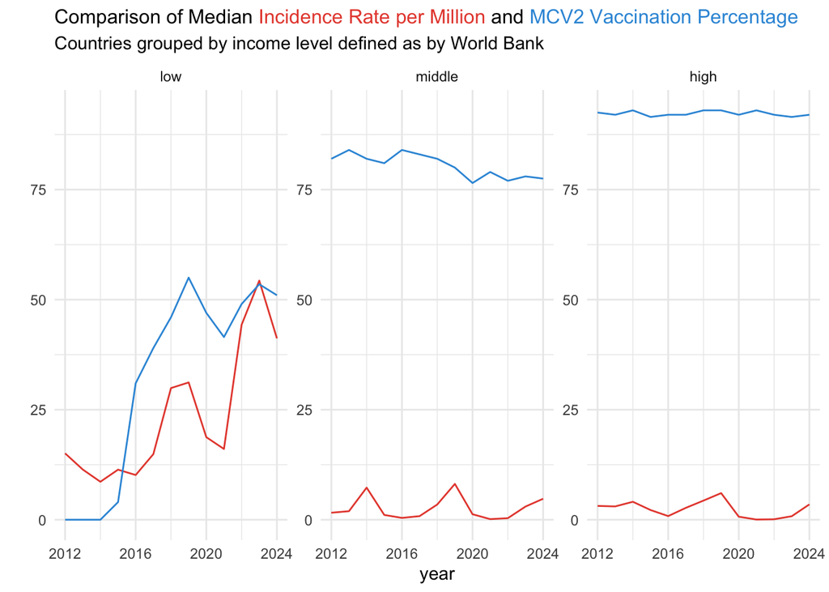

**Figure 3.** Time series plot of incidence rate and vaccination percentage from 2012 - 2024.

```r
metadata |>
  select(region, country, year, measles_incidence_rate_per_1000000_total_population, total_population, mcv2, GDP_per_capita) |>
  filter(year != 2025 & !is.na(region) & !is.na(GDP_per_capita)) |>
  mutate(gdp_group = factor(
          case_when(
            GDP_per_capita <= 1145 ~ "low",
            GDP_per_capita <= 14005 ~ "middle",
            GDP_per_capita > 14005 ~ "high"
            ),
          levels = c("low", "middle", "high")
          )
        ) |>
  group_by(gdp_group, year) |>
  summarize(Vaccination = median(mcv2 * 100, na.rm = TRUE),
            Incidence = median(measles_incidence_rate_per_1000000_total_population, na.rm = TRUE),
            .groups = "drop") |>
  pivot_longer(
    cols = c(Incidence, Vaccination),
    names_to = "type",
    values_to = "rate"
  ) |>
  ggplot(aes(x = year, y = rate, color = type)) +
  geom_line() +
  scale_color_manual(values = c("Incidence" = "#e74c3c", "Vaccination" = "#3498db")) +
  facet_wrap(~ gdp_group, axes = "all") +
  labs(
    title = "Comparison of Median <span style='color:#e74c3c;'>Incidence Rate per Million</span> and <span style='color:#3498db;'>MCV2 Vaccination Percentage</span>",
    subtitle = "Countries grouped by income level defined as by World Bank",
    y = "",
    alt = "A figure that displays line charts with median measles incidence and MCV2 vaccination rates per million people from 2012 to 2024, faceted by income classification. Vaccination rate are generally higher as the income classification group rises, which indicates generally that richer countries are more vaccinated. Low income countries have a more direct relationship between these two variables.",
    color = "Type of Rate") +
  scale_x_continuous(breaks = seq(2012, 2024, by = 4),
                    ) +
  theme_minimal() +
  theme(
    plot.title = element_markdown(size = 12),
    legend.position = "none"
    )
```

```r
metadata |>
  filter_out(is.na(region)) |>
  group_by(region) |>
  summarize(mean_GDP = mean(GDP_per_capita, na.rm = TRUE),
            mean_mcv2 = mean(mcv2, na.rm = TRUE)) |>
  arrange(mean_GDP) |>
  gt() |>
  data_color(columns = mean_GDP, method = "numeric",
             fn = col_numeric(palette = c("#ecf0f1", "#3498db"),
                              domain = NULL)) |>
  data_color(columns = mean_mcv2, method = "numeric",
             fn = col_numeric(palette = c("#ecf0f1", "#29c1a3"),
                              domain = NULL)) |>
  fmt_currency(columns = mean_GDP, currency = "USD") |>
  fmt_percent(columns = mean_mcv2, decimals = 1) |>
  cols_align(align = "left", columns = region) |>
  tab_style(style = cell_text(weight = "bold"),
            locations = cells_column_labels()) |>
  tab_header(title = md("Average GDP per Capita and MCV2 Vaccine Rate by Region")) |>
  tab_caption(caption = md("**Table 4** Side-by-side comparison of mean GDP and MCV2 Percentage")) |>
  cols_label(region = "Region", mean_GDP = "Mean GDP (USD)", mean_mcv2 = "Mean MCV2 Coverage")
```

**Table 4** Side-by-side comparison of mean GDP and MCV2 Percentage

Average GDP per Capita and MCV2 Vaccine Rate by Region

| Region | Mean GDP (USD) | Mean MCV2 Coverage |
| --- | --- | --- |
| Africa | $2,307.99 | 36.3% |
| South East Asia | $4,044.05 | 79.1% |
| Americas | $13,638.39 | 74.1% |
| Eastern Mediterranean | $14,272.35 | 76.3% |
| Western Pacific | $16,535.63 | 76.5% |
| Europe | $28,913.33 | 89.1% |

Table 4 shows that a higher average region GDP is generally associated with a higher measles vaccination rate (with the exception of South East Asia, which has the second-lowest mean GDP but the second-highest MCV2 rate). Africa has the lowest GDP and the lowest MCV2, while Europe has the highest in both.